# MICB425 portfolio

Polina Beskrovnaya (38929148)

version Апрель 24, 2018

# Module 01 - Origins and Earth Systems

## Data science Friday

### Installation check

Space for installation screenshots:

[figure not shown]

[figure not shown]

### Portfolio repo setup

**code you used to create, initialize, and push your portfolio repo to GitHub:**

cd ~/Documents/MICB425_portfolio

git init

git add .

git commit -m “First commit”

git remote add origin https://remote_repository_URL

git remote -v

git push -u origin master

### RMarkdown pretty PDF challenge

**Paste your code from the in-class activity of recreating the example PDF:**

This is my attempt at creating a pretty document in R Studio. I am sort of trying, but coding is very confusing.

The following assignment is an exercise for the reproduction of this .html document using the RStudio and RMarkdown tools we?ve shown you in class. Hopefully by the end of this, you won?t feel at all the way this poor PhD student does. We?re here to help, and when it comes to R, the internet is a really valuable resource. This open-source program has all kinds of tutorials online.

*And here is a comic I like a little bit more:*

[figure not shown]

**A slightly more relatable comic…**

#### Challenge Goals

The goal of this R Markdown html challenge is to give you an opportunity to play with a bunch of different RMarkdown formatting. Consider it a chance to flex your RMarkdown muscles. Your goal is to write your own RMarkdown that rebuilds this html document as close to the original as possible. So, yes, this means you get to copy my irreverant tone exactly in your own Markdowns. It?s a little window into my psyche. Enjoy =)

**hint: go to the [PhD Comics website](http://phdcomics.com) to see if you can find the image above** *If you can?t find that exact image, just find a comparable image from the PhD Comics website and include it in your markdown*

##### I am not sure I am enjoying this assignment yet.

And my feelings deserve a whole separate section. You may even have noticed that this is under a **different** level header.

And since we are sharing comics, I want to make room for one more:

[figure not shown]

[Explosm.net](http://explosm.net)

#### Here’s a header! Mathy header.

Let?s be honest, this header is a little arbitrary. But show me that you can reproduce headers with different levels please. This is a level 3 header, for your reference (you can most easily tell this from the table of contents).

##### Another header, now with maths

Perhaps you?re already really confused by the whole markdown thing. Maybe you?re so confused that you?ve forgotton how to add. Never fear! A calculator R is here:

I’m not sure why we are doing math, but:

```r
666+13131313131313134
```

```
## [1] 1.313131e+16
```

**Wow, this worked!** I am shocked it<sup>actually</sup> worked…

#### Why I am taking this class:

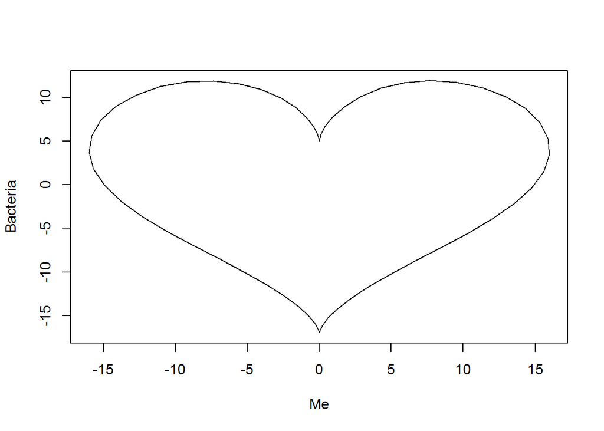

```r
dat<- data.frame(t=seq(0, 2*pi, by=0.1) )
 xhrt <- function(t) 16*sin(t)^3
 yhrt <- function(t) 13*cos(t)-5*cos(2*t)-2*cos(3*t)-cos(4*t)
 dat$y=yhrt(dat$t)
 dat$x=xhrt(dat$t)
 with(dat, plot(x,y, type="l", xlab="Me", ylab="Bacteria"))
```

Is it bad that I took pretty codes from [somewhere?](https://stackoverflow.com/questions/8082429/plot-a-heart-in-r)

#### Here is a table:

Or maybe, after you?ve added those numbers, you feel like it?s about time for a table! I?m going to leave all the guts of the coding here so you can see how libraries (R packages) are loaded into R (more on that later). It?s not terribly pretty, but it hints at how R works and how you will use it in the future. The summary function used below is a nice data exploration function that you may use in the <sup>future</sup>.

```r
library(knitr)
kable(summary(cars),caption="I made this table with kable in the knitr package library, but I'm not sure why")
```

I made this table with kable in the knitr package library, but I’m not sure why

|  | speed | dist |
| --- | --- | --- |
|  | Min. : 4.0 | Min. : 2.00 |
|  | 1st Qu.:12.0 | 1st Qu.: 26.00 |
|  | Median :15.0 | Median : 36.00 |
|  | Mean :15.4 | Mean : 42.98 |
|  | 3rd Qu.:19.0 | 3rd Qu.: 56.00 |
|  | Max. :25.0 | Max. :120.00 |

#### Here’s another table:

| Organism | Level of coolness(%) |
| --- | --- |
| Human | 0 |
| Giraffe | 75 |
| Polar bear | 100 |
| Prokaryote | 100 |

#### The big finale.

This gif sums up me vs. all the assignment deadlines and grad school application process this semester:

[figure not shown]

### ggplot exercises

Code pasted here:

```r
library(tidyverse)
library(phyloseq)
```

```r
read.table(file="Saanich.metadata.txt", header=TRUE, row.names=1, sep="\t", na.strings="NAN")
```

[output not shown]

[output cut: 30 more lines]

```
## SI072_S3_020       28.763    21.923
## SI072_S3_040       29.352    22.619
## SI072_S3_060       30.115    23.365
## SI072_S3_075       30.551    23.714
## SI072_S3_085       30.745    23.858
## SI072_S3_090       30.803    23.895
## SI072_S3_097       30.838    23.915
## SI072_S3_100       30.872    23.933
## SI072_S3_110       30.932    23.977
## SI072_S3_120       31.007    24.026
## SI072_S3_135       31.088    24.076
## SI072_S3_150       31.164    24.118
## SI072_S3_165       31.197    24.138
## SI072_S3_185       31.231    24.157
## SI072_S3_200       31.248    24.167
```

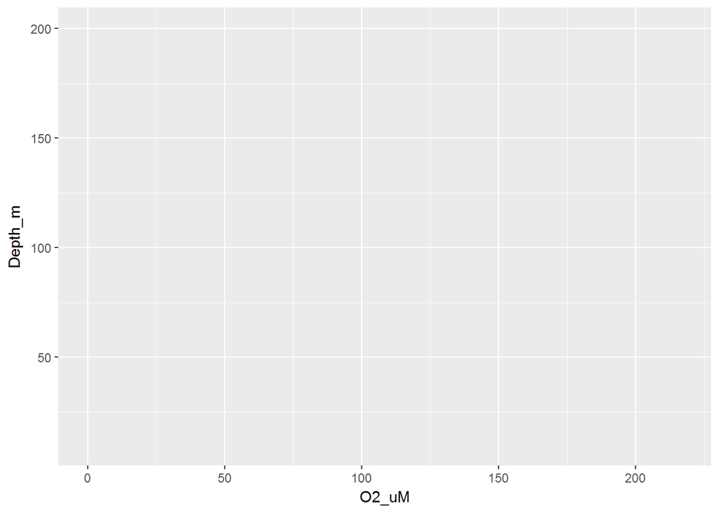

```r
metadata = read.table(file="Saanich.metadata.txt", header=TRUE, row.names=1, sep="\t")
load("phyloseq_object.RData")

#The base function of any plot from ggplot is unsurprisingly the ggplot function.
#This function takes in the data and basic aesthetics of the plot,
#like the x- and y-axis variables, but does not specify the way
#in which you want to plot the data (like dots, bars, etc.).
#So, if we try to plot depth by oxygen (O2) with just ggplot,
#we get a plot with the correct axes but no actual data.
ggplot(metadata, aes(x=O2_uM, y=Depth_m))
```

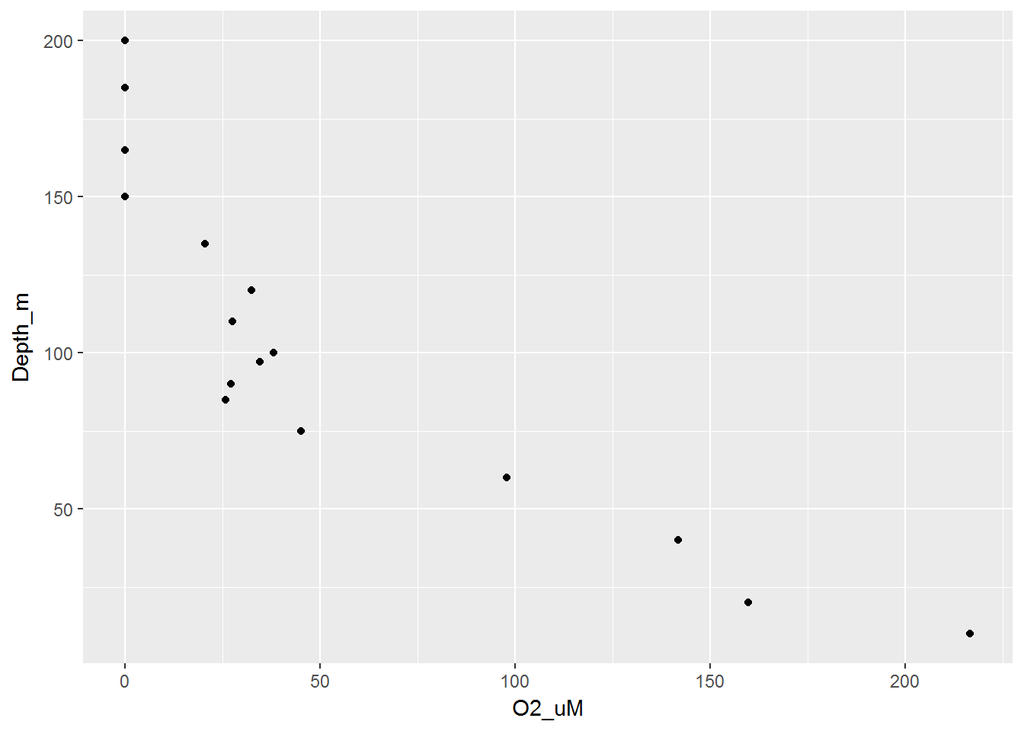

```r
#To add in the data, we must specify a geom. To get a dot plot, we will use geom_point
ggplot(metadata, aes(x=O2_uM, y=Depth_m)) +
  geom_point()
```

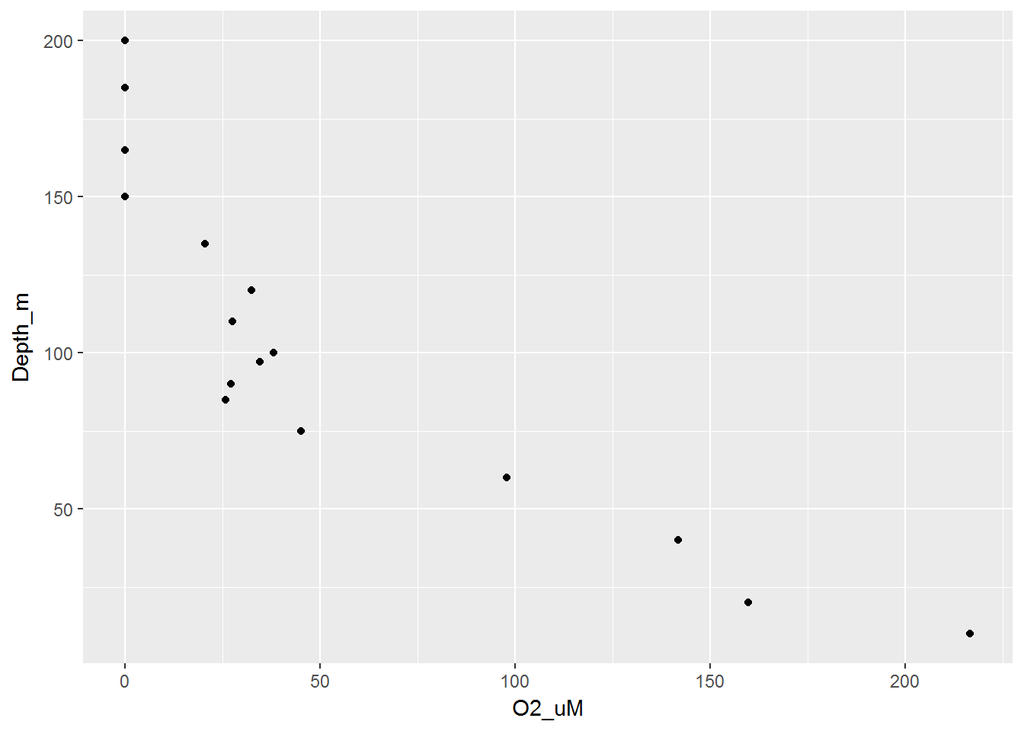

```r
#So, the above is equivalent to
ggplot(metadata) +
  geom_point(aes(x=O2_uM, y=Depth_m))
```

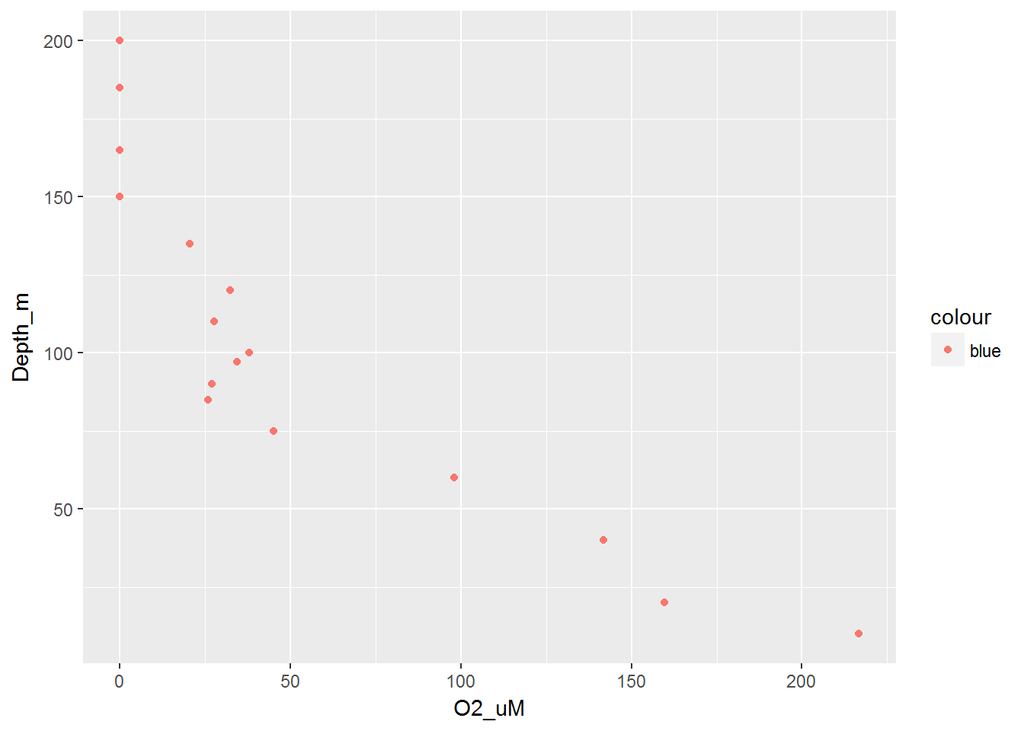

```r
#We can change the color (outline and fill), shape, or size of our points
ggplot(metadata, aes(x=O2_uM, y=Depth_m, color="blue")) +
  geom_point()
```

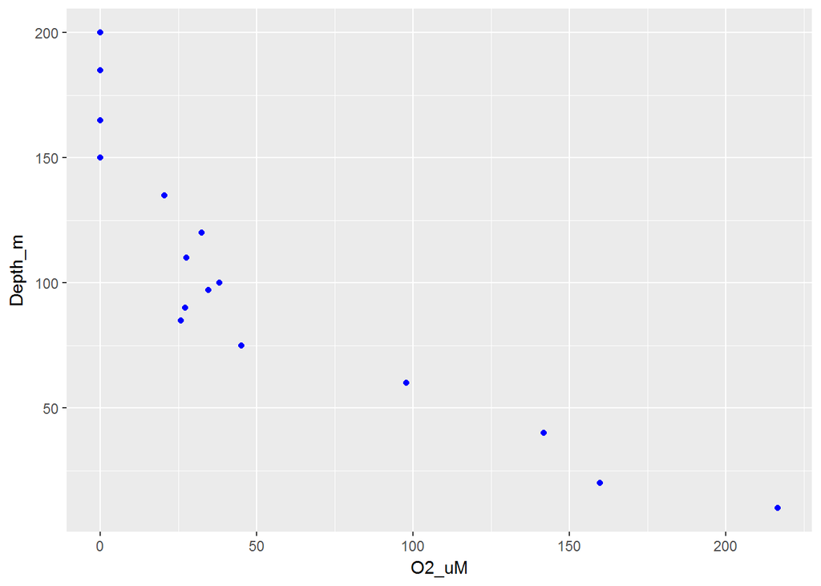

```r
#But wait! ThatвЂ™s not blue! What happened?
#Within ggplot, you can specify attributes that are part of the overall plot
#(everything that shows up if you only use ggplot, no geom)
#but not attributes associated with a specific geom.
#In this case, the dots are there because of geom_point
#so we must change their color within the geom function.
ggplot(metadata, aes(x=O2_uM, y=Depth_m)) +
  geom_point(color="blue")
```

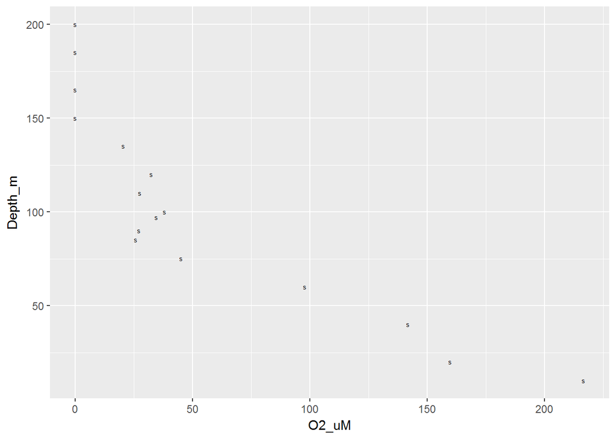

```r
#The same holds for changing shape and size such as in
ggplot(metadata, aes(x=O2_uM, y=Depth_m)) +
  geom_point(shape="square")
```